# Week11_Wednesday slides

## Week 11 Wednesday

Wednesday, April 8, 2026

**Announcements**

- A07 due today
- A08 (project proposal) due 4/17

**Goals**

- Mapping and Path Planning

## Romi feedback control hints:

Helpful to:

- Consider some "special cases" that are easy to model
- Try feedback control using GPS for position rather than odometry

## Mapping is very important (and very hard)

- Where am I? (localization)
- Where is everything else? (mapping)
- How do I build a map, *and* know where I am? (simultaneous localization and mapping)

### GridSLAM in Javascript by Tommy Cohn:

[original site here](http://tommycohn.com/Occupancy-Grid-SLAM-JS/)

[interactive chart not shown]

## The Occupancy Grid Map

An occupancy grid map, in its simplest form, is just a matrix of ones and zeros. Normally, a "1" in a matrix cell means that the cell is "occupied" and a zero means that it is not. Consider the example in the figure below.

[figure not shown]

### Converting between true coordinates and map cell indices

Suppose we are considering a cell at row $i$ and column $j$ in an occupancy grid map $\mathcal{M}(m\times n)$, where (for now) we assume the map is square and $m=n$. We will further assume standard "map" coordinates apply, with an origin in the bottom left with $X$ pointing along the columns, and $Y$ pointing *upward* along the rows. Note that this means that the point $X=0,Y=0$ will be at the very bottom edge of the cell at row $m$, column $0$.

.

.

.

## Mapping with "perfect" ego-motion and landmark measurements

```
import numpy as np
m = #map rows
n = #map columns
map_L = #map size
map_D = #map size
#initialize an occupancy grid map (all zeros)
M = np.zeros((m,n))
#for each timestep:
while romi.simromi.step(timestep) != -1:
    X,Y,Psi = updateRomiPose()#function would measure current pose of Romi using GPS/compass or odometry
    proxReading = romi.proxFrontVal #measure current "distance" in counts to object in front of Romi
    if(proxReading<thresh): #only continue if we aren't measuring 'infinite' distance
        dist = countsToMeters(proxReading) #function would convert prox reading to distance
        aX_obstacle,aY_obstacle = findAllocentricObstacle(X,Y,Psi,dist) #function would find global X,Y of obstacle
        j_obstacle,i_obstacle = positionToCell(aX_obstacle,aY_obstacle,map_L,map_d)
        M[i,j] = 1#occupy this cell!
    mLeft,mRight,s1,s2,s3 = getRomiCommands() #maybe this is an FSM
    romi.update(mLeft,mRight,s1,s2,s3) #update the Romi
```

## Using maps: Planning a path around obstacles to reach a goal

Consider the following map, where the Romi's goal is to get the Apple. The green path is shorter by two cells. But how would the Romi "know" this? How could this be determined automatically?

[figure not shown]

### Dijkstra's Algorithm

Lots of very smart people have worked on path planning for a long time, and the algorithm we will start with here is called Dijkstra's algorithm. [It was invented in 1959](https://www.cs.yale.edu/homes/lans/readings/routing/dijkstra-routing-1959.pdf). There's a great [blog post](https://realitybytes.blog/2017/07/11/graph-based-path-planning-dijkstras-algorithm/) about this algorithm *with an implementation* that has been loaded into the Week11 sample world of your ES302_Webots repository. These notes are based on that blog post. **You should read the original post!!**

### Dijkstra's Algorithm

Dijkstra's algorithm looks at a grid map as a "graph" (in the mathematical sense). In a "graph" representation of the occupancy grid, each cell is a "node" in the graph, and it is connected by "edges" to each node "above" it, "below" it, to its "left," and to its "right." This is shown below.

[figure not shown]

### Dijkstra's Algorithm

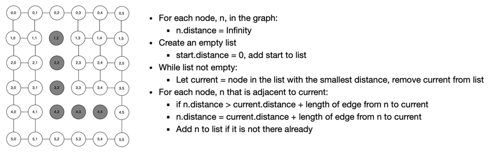

### Dijkstra's Algorithm

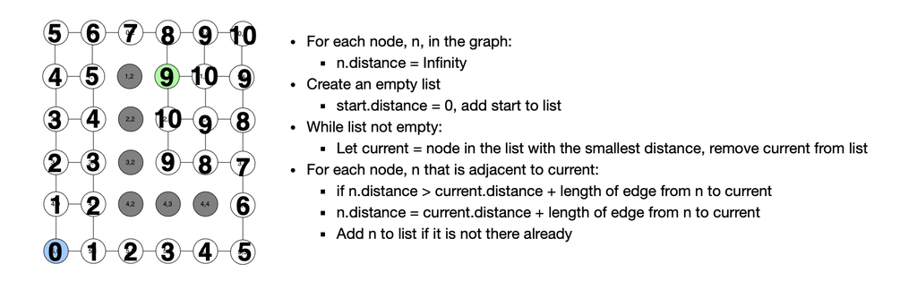

### Dijkstra's Algorithm

First, set up a map as an array:

```
Map:
[[0 0 0 0 0 0]
 [0 0 1 0 0 0]
 [0 0 1 0 0 0]
 [0 0 1 0 0 0]
 [0 0 1 1 1 0]
 [0 0 0 0 0 0]]
```

Then, we can set up our goal x and y, along with start x and y.

```
Start X,Y = 0,5
Goal X,Y = 3,1
```

Next, we can call the function to see what our optimal path is!

```
Goal found!
Generating path...
Path:
[[0, 5], [0, 5], [0, 4], [0, 3], [0, 2], [0, 1], [0, 0], [1, 0], [2, 0], [3, 0], [3, 1]]
```

As you can see, this is not *exactly* the same path as we generated "by eye" because it goes "up" before going right, but it is equivalently short! We can visualize the map using matplotlib's "imshow" functionality. We can then plot the desired path on top of the image.

### Dijkstra's Algorithm

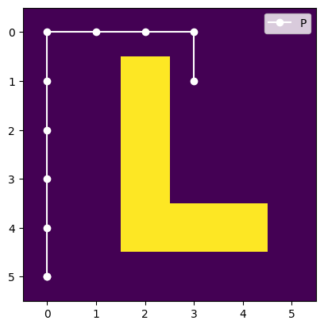